# Flexible Damage Functions

Author

James Rising, Sebastian Cadavid Sanchez, Climate Impact Lab

Published

April 30, 2026

## 0.1 Labor: Low Risk Country

Flexible damage function parameters at the Country level.

**Outcome units:** `portion` — dimensionless fraction of labor productivity for low risk workers, rebased to 2005 baseline; population-weighted aggregation to country

$$D_{it} = (\alpha_i T_t + \beta_i T_t^2) \cdot Y_{it}^{\gamma}$$

where $\gamma$ is the income elasticity (fitted globally), $\alpha_i$ is the linear coefficient, and $\beta_i$ is the quadratic coefficient.

# 1 Global Estimation

## 1.1 Income Elasticity Estimation

The income elasticity $\gamma$ is estimated using a fixed-effects regression:

$$y_{it} = \gamma \cdot \log(Y_{it}) + \mu_{g(i,T)} + \nu_t + \varepsilon_{it}$$

where $\mu_{g(i,T)}$ are region-by-temperature-bin fixed effects and $\nu_t$ are year fixed effects.

Table 1: Income Elasticity (Gamma) Estimation Results

| Statistic | Value |
| --- | --- |
| Income elasticity ($\gamma$) | -0.0052 |
| Standard error | 2.03e-03 |
| 95% CI | [-0.0092, -0.0013] |
| R-squared | 0.6026 |
| Observations | 79,181,550 |
| Regions | 245 |
| Gamma quantiles | 19 |

# 2 Parameter Distributions

## 2.1 8-Panel Summary

Row 1: gamma, alpha, beta, rsqr1. Row 2: rho, zeta, eta, rsqr2.

```
Using median gamma: -0.005238, 245 rows (of 4,655 total)
```

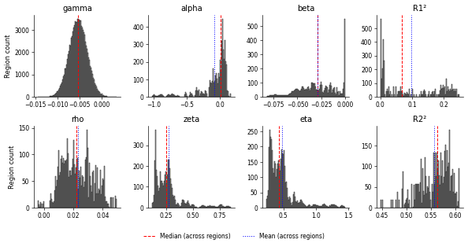

Figure 1: Distribution of Regional Parameters

## 2.2 Projection Equation and Parameter Definitions

The estimated parameters are used to project damages via Monte Carlo sampling:

$$D_{it}^k = (\hat{\alpha}_{ik} T_t + \hat{\beta}_{ik} T_t^2) Y_{it}^{\hat{\gamma}_k} + \hat{\theta}_{ik} T_t Y_{it}^{\hat{\gamma}_k} + \hat{\phi}_{it}^k$$

where $k$ indexes the Monte Carlo draw. The parameters in each row of the output CSV control distinct components of this equation:

- **gamma**: income elasticity $\hat{\gamma}_k$, one of 19 quantile values drawn from $N(\hat{\gamma}, SE(\hat{\gamma}))$
- **alpha, beta**: linear and quadratic temperature coefficients; $\hat{\alpha}_{ik}$ and $\hat{\beta}_{ik}$ are drawn from the joint normal defined by the VCV below
- **sigma11, sigma12, sigma22**: variance-covariance matrix of $(\alpha, \beta)$, used for joint uncertainty sampling
- **rho**: correlation between regional and global polynomial residuals $\rho_i$, used to maintain spatial covariance across regions in Monte Carlo draws
- **zeta**: temperature-dependent error scale $\zeta_{ik}$; the run-specific error term $\hat{\theta}_{ik}$ is drawn from $N(0, \zeta_{ik})$
- **eta**: residual noise standard deviation $\eta_{ik}$; the annual noise $\hat{\phi}_{it}^k$ is drawn from $N(0, \eta_{ik})$
- **rsqr1, rsqr2**: polynomial fit quality and error model fit, respectively

## 2.3 Summary Statistics

Table 2: Regional Parameter Summary

| Parameter | Mean | Median | Std | Min | Max | N |
| --- | --- | --- | --- | --- | --- | --- |
| alpha | -0.07894 | 0.008322 | 0.2253 | -0.9939 | 0.1623 | 245 |
| beta | -0.02851 | -0.02875 | 0.01971 | -0.07945 | 0 | 245 |
| rho | 0.02309 | 0.02215 | 0.01057 | -0.003538 | 0.04912 | 245 |
| zeta | 0.2746 | 0.248 | 0.1385 | 0.1242 | 0.831 | 245 |
| eta | 0.4841 | 0.4354 | 0.2214 | 0.2469 | 1.405 | 245 |
| rsqr1 | 0.09805 | 0.06777 | 0.08855 | 0.0008208 | 0.2481 | 245 |
| rsqr2 | 0.5565 | 0.563 | 0.03262 | 0.4471 | 0.6079 | 245 |

# 3 Spaghetti Curves

Regional damage function curves showing D(T) = αT + βT² for sampled regions.

[interactive chart not shown]

Figure 2: Regional Damage Functions

# 4 Zero Crossings

The zero crossing (extremum) of the parabola occurs at $T^* = -\alpha / (2\beta)$.

Table 3: Zero Crossing Statistics

| Category | Count | Percentage |
| --- | --- | --- |
| β = 0 (no crossing) | 25 | 10.2% |
| T > 20°C (beyond graph) | 7 | 2.9% |
| T < 0°C (negative crossing) | 115 | 46.9% |
| Valid crossings (0-20°C) | 98 | 40.0% |

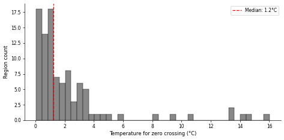

Figure 3: Distribution of Zero Crossing Temperatures

# 5 Slope Analysis

Maximum slope between 0 and 10°C: $\frac{dM}{dT} = \alpha + 2\beta T$

The maximum occurs at either T=0 or T=10 (endpoints of interval).

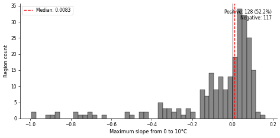

Figure 4: Distribution of Maximum Slopes (0-10°C)

*Convexity analysis omitted (beta constraint active).*

# 6 R-squared Analysis

## 6.1 Polynomial Fit Quality (rsqr1)

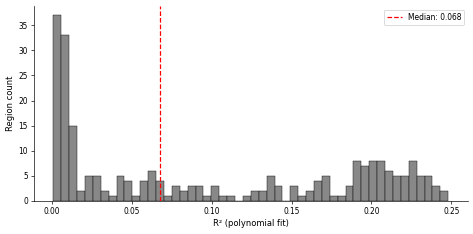

Figure 5: Regional Fit Quality (R-squared)

## 6.2 Error Model R-squared (rsqr2) Quantiles

Table 4: rsqr2 Quantiles

| 0% (Min) | 25% | 50% (Median) | 75% | 100% (Max) |
| --- | --- | --- | --- | --- |
| 0.4471 | 0.5347 | 0.5630 | 0.5821 | 0.6079 |

# 7 Modelled Variance

Modelled variance statistic: $1 - \frac{\sum_i \eta_i^2}{\sum_i D_i^2}$

Table 5: Modelled Variance Statistics

| Statistic | Value |
| --- | --- |
| Modelled variance | 0.6313 |
| Sum(η²) | 69.3743 |
| Sum(D²) at T=3.0°C | 188.1371 |
| N regions | 245 |

# 8 Best- and Worst-Fitting Regions

The 3 worst- and 3 best-fitting regions by R-squared, with raw simulation data overlaid on the fitted polynomial curve. **Red rows = worst fits**, **green rows = best fits**.

Table 6: Best- and worst-fitting regions

Top 3 best fit (R²) Top 3 worst fit (R²)

[output not shown]

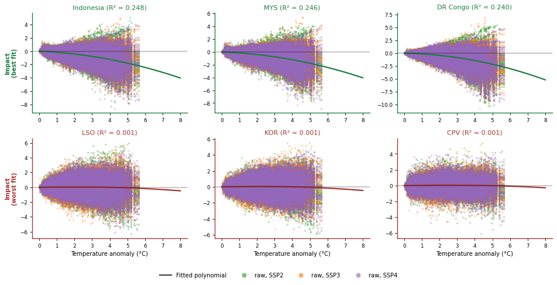

# 9 Regional Parameter Maps

Maps of key parameters at the **country** level. Red = negative (damage increases with T), Blue = positive.

## 9.1 Alpha (Linear Coefficient)

Alpha ($\alpha$) represents the linear sensitivity to temperature. Regions with negative alpha experience damage that increases with the first degree of warming.

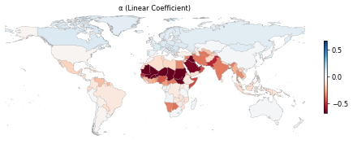

Figure 7: α (linear coefficient)

## 9.2 Beta (Quadratic Coefficient)

Beta ($\beta$) represents the curvature of the damage function.

The concavity ($\beta \leq 0$) constraint is enforced for this sector, meaning optimal temperature exists, damages accelerate beyond it.

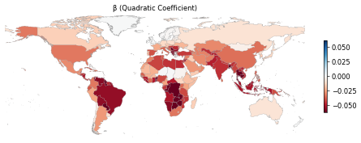

Figure 8: β (quadratic coefficient)

## 9.3 R-squared (Fit Quality)

$R^2$ measures the polynomial fit quality. Higher values indicate that the quadratic form captures more of the variance in the data.

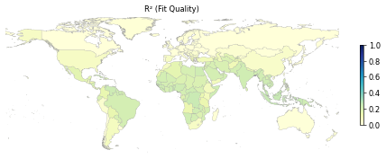

Figure 9: R² (stage 1 fit quality)

# 10 F2: Flex vs Raw Comparison

Comparison of flexible damage function predictions against raw simulation means.

For each scenario (RCP × SSP × Model), we compute at the final year:

- **Flex predicted**: $(\alpha \cdot T + \beta \cdot T^2) \cdot Y^\gamma$
- **Raw actual**: The outcome variable (y) from the source data

**Year 2099**: 1,480,050 rows

**rcp45**

**SSP2**

**high**

**Correlation:** 0.9764 | **RMSE:** 0.714704 | **Sign agreement:** 96.7%

[interactive chart not shown]

Top 5 best predicted Top 5 worst predicted

Year 2099 · T<sub>mean</sub> across these regions: 1.96°C

| Region | Raw | Flex | Residual |
| --- | --- | --- | --- |
| MUS | 0.061 | 0.0596 | -0.00139 |
| WSM | -0.06 | -0.0619 | -0.00182 |
| VGB | -0.0244 | -0.0182 | 0.0062 |
| NRU | 0.0277 | 0.0211 | -0.00652 |
| SWZ | -0.108 | -0.102 | 0.00661 |
| MLI | -5.23 | -1.75 | 3.48 |
| NER | -5.1 | -1.84 | 3.25 |
| IRQ | -4.36 | -1.51 | 2.85 |
| SDN | -4.68 | -1.83 | 2.85 |
| MRT | -4.52 | -1.68 | 2.84 |

**low**

**Correlation:** 0.9690 | **RMSE:** 0.948965 | **Sign agreement:** 97.1%

[interactive chart not shown]

Top 5 best predicted Top 5 worst predicted

Year 2099 · T<sub>mean</sub> across these regions: 1.96°C

| Region | Raw | Flex | Residual |
| --- | --- | --- | --- |
| NCL | 0.0683 | 0.0661 | -0.00222 |
| SLB | -0.0605 | -0.0563 | 0.00424 |
| MKD | 0.0278 | 0.0226 | -0.00525 |
| BEL | 0.102 | 0.111 | 0.00846 |
| MNP | -0.0262 | -0.0166 | 0.00954 |
| NER | -6.58 | -1.85 | 4.72 |
| BFA | -6.25 | -1.7 | 4.55 |
| MLI | -6.12 | -1.76 | 4.36 |
| TCD | -5.7 | -1.71 | 3.99 |
| MRT | -5.39 | -1.69 | 3.7 |

**SSP3**

**high**

**Correlation:** 0.9735 | **RMSE:** 1.090224 | **Sign agreement:** 97.1%

[interactive chart not shown]

Top 5 best predicted Top 5 worst predicted

Year 2099 · T<sub>mean</sub> across these regions: 1.96°C

| Region | Raw | Flex | Residual |
| --- | --- | --- | --- |
| VGB | -0.0205 | -0.0183 | 0.00225 |
| GIB | 0.0234 | 0.0297 | 0.00636 |
| VCT | 0.0103 | 0.00137 | -0.00893 |
| LCA | -0.0282 | -0.0189 | 0.00928 |
| WSM | -0.0715 | -0.0622 | 0.00932 |
| MLI | -7.06 | -1.76 | 5.3 |
| NER | -7.01 | -1.86 | 5.15 |
| SDN | -6.32 | -1.84 | 4.48 |
| BFA | -6.05 | -1.7 | 4.35 |
| TCD | -5.96 | -1.71 | 4.25 |

**low**

**Correlation:** 0.9575 | **RMSE:** 1.302126 | **Sign agreement:** 94.7%

[interactive chart not shown]

Top 5 best predicted Top 5 worst predicted

Year 2099 · T<sub>mean</sub> across these regions: 1.96°C

| Region | Raw | Flex | Residual |
| --- | --- | --- | --- |
| GRD | -0.0313 | -0.032 | -6.27e-4 |
| KGZ | -0.0368 | -0.0294 | 0.00738 |
| WSM | -0.0532 | -0.062 | -0.00875 |
| VAT | -0.0805 | -0.0711 | 0.00939 |
| TWN | 0.0288 | 0.0176 | -0.0112 |
| NER | -8.24 | -1.87 | 6.37 |
| MLI | -8.03 | -1.77 | 6.26 |
| BFA | -7.92 | -1.72 | 6.2 |
| TCD | -7.44 | -1.72 | 5.71 |
| MRT | -6.85 | -1.7 | 5.15 |

**SSP4**

**high**

**Correlation:** 0.9490 | **RMSE:** 1.072403 | **Sign agreement:** 97.6%

[interactive chart not shown]

Top 5 best predicted Top 5 worst predicted

Year 2099 · T<sub>mean</sub> across these regions: 1.96°C

| Region | Raw | Flex | Residual |
| --- | --- | --- | --- |
| PRT | 0.0911 | 0.0905 | -6.18e-4 |
| NRU | 0.0198 | 0.0212 | 0.00137 |
| COM | -0.0376 | -0.0318 | 0.00579 |
| ITA | 0.0254 | 0.0186 | -0.00679 |
| AUS | -0.00435 | -0.0114 | -0.00708 |
| MLI | -7.39 | -1.77 | 5.63 |
| NER | -7.41 | -1.86 | 5.55 |
| SDN | -7.02 | -1.85 | 5.17 |
| BFA | -6.3 | -1.71 | 4.59 |
| TCD | -5.97 | -1.71 | 4.26 |

**low**

**Correlation:** 0.9632 | **RMSE:** 1.214285 | **Sign agreement:** 97.6%

[interactive chart not shown]

Top 5 best predicted Top 5 worst predicted

Year 2099 · T<sub>mean</sub> across these regions: 1.96°C

| Region | Raw | Flex | Residual |
| --- | --- | --- | --- |
| ABW | 0.0576 | 0.0562 | -0.00147 |
| LUX | 0.111 | 0.108 | -0.00288 |
| SLB | -0.0617 | -0.0565 | 0.00512 |
| SRB | -0.0284 | -0.0227 | 0.00569 |
| NRU | 0.0272 | 0.0213 | -0.00593 |
| BFA | -7.59 | -1.71 | 5.88 |
| NER | -7.55 | -1.86 | 5.69 |
| MLI | -7.4 | -1.77 | 5.63 |
| TCD | -6.81 | -1.72 | 5.09 |
| SDN | -6.61 | -1.85 | 4.76 |

**rcp85**

**SSP2**

**high**

**Correlation:** 0.9655 | **RMSE:** 3.091894 | **Sign agreement:** 94.3%

[interactive chart not shown]

Top 5 best predicted Top 5 worst predicted

Year 2099 · T<sub>mean</sub> across these regions: 4.20°C

| Region | Raw | Flex | Residual |
| --- | --- | --- | --- |
| NCL | 0.136 | 0.137 | 0.00163 |
| STP | 0.184 | 0.173 | -0.0102 |
| VUT | 0.0389 | 0.0533 | 0.0144 |
| WLF | 0.0817 | 0.0615 | -0.0201 |
| CAN | 0.141 | 0.166 | 0.025 |
| MLI | -17.5 | -3.95 | 13.6 |
| NER | -17.2 | -3.95 | 13.3 |
| SDN | -16.5 | -3.95 | 12.6 |
| BFA | -15.4 | -3.8 | 11.6 |
| TCD | -14.6 | -3.65 | 10.9 |

**low**

**Correlation:** 0.9556 | **RMSE:** 3.788198 | **Sign agreement:** 95.1%

[interactive chart not shown]

Top 5 best predicted Top 5 worst predicted

Year 2099 · T<sub>mean</sub> across these regions: 4.20°C

| Region | Raw | Flex | Residual |
| --- | --- | --- | --- |
| KOR | 0.0124 | -0.0046 | -0.017 |
| GBR | 0.193 | 0.219 | 0.0259 |
| NCL | 0.163 | 0.137 | -0.0259 |
| LSO | -0.0394 | -0.00857 | 0.0308 |
| CAN | 0.134 | 0.166 | 0.0315 |
| NER | -21.3 | -3.98 | 17.3 |
| BFA | -20.8 | -3.84 | 16.9 |
| MLI | -19.9 | -3.97 | 15.9 |
| TCD | -18.6 | -3.67 | 15 |
| SDN | -18.2 | -3.96 | 14.2 |

**SSP3**

**high**

**Correlation:** 0.9620 | **RMSE:** 3.958676 | **Sign agreement:** 98.4%

[interactive chart not shown]

Top 5 best predicted Top 5 worst predicted

Year 2099 · T<sub>mean</sub> across these regions: 4.20°C

| Region | Raw | Flex | Residual |
| --- | --- | --- | --- |
| KNA | -0.0275 | -0.0268 | 6.49e-4 |
| FJI | -0.0874 | -0.0866 | 7.53e-4 |
| TCA | -0.0749 | -0.0859 | -0.011 |
| SVK | 0.033 | 0.0211 | -0.0119 |
| PRT | 0.00192 | 0.0162 | 0.0143 |
| NER | -21.7 | -3.99 | 17.7 |
| MLI | -21.5 | -3.99 | 17.5 |
| SDN | -20.1 | -3.97 | 16.1 |
| BFA | -19.6 | -3.83 | 15.8 |
| TCD | -18.4 | -3.67 | 14.7 |

**low**

**Correlation:** 0.9470 | **RMSE:** 4.873440 | **Sign agreement:** 96.3%

[interactive chart not shown]

Top 5 best predicted Top 5 worst predicted

Year 2099 · T<sub>mean</sub> across these regions: 4.20°C

| Region | Raw | Flex | Residual |
| --- | --- | --- | --- |
| JPN | -0.0011 | 1.20e-4 | 0.00121 |
| TCA | -0.0818 | -0.0861 | -0.00432 |
| KNA | -0.0411 | -0.0269 | 0.0143 |
| URY | -0.0738 | -0.0563 | 0.0176 |
| CZE | 0.14 | 0.105 | -0.0348 |
| NER | -24.9 | -4.02 | 20.8 |
| BFA | -24.5 | -3.87 | 20.7 |
| MLI | -24.4 | -4.01 | 20.4 |
| TCD | -22.9 | -3.71 | 19.2 |
| SDN | -23 | -3.99 | 19 |

**SSP4**

**high**

**Correlation:** 0.9373 | **RMSE:** 4.083208 | **Sign agreement:** 94.3%

[interactive chart not shown]

Top 5 best predicted Top 5 worst predicted

Year 2099 · T<sub>mean</sub> across these regions: 4.20°C

| Region | Raw | Flex | Residual |
| --- | --- | --- | --- |
| PYF | 0.136 | 0.129 | -0.00774 |
| RWA | 0.00529 | 0.0133 | 0.00802 |
| NCL | 0.122 | 0.137 | 0.0151 |
| CPV | 0.0473 | 0.0316 | -0.0157 |
| MNG | 0.267 | 0.248 | -0.019 |
| NER | -23.1 | -4 | 19.1 |
| MLI | -22.7 | -4 | 18.7 |
| SDN | -22.3 | -3.99 | 18.3 |
| BFA | -20.8 | -3.84 | 17 |
| TCD | -19.1 | -3.68 | 15.4 |

**low**

**Correlation:** 0.9533 | **RMSE:** 4.671320 | **Sign agreement:** 97.6%

[interactive chart not shown]

Top 5 best predicted Top 5 worst predicted

Year 2099 · T<sub>mean</sub> across these regions: 4.20°C

| Region | Raw | Flex | Residual |
| --- | --- | --- | --- |
| SMR | 0.102 | 0.0839 | -0.0182 |
| FJI | -0.0649 | -0.0865 | -0.0216 |
| AUS | -0.141 | -0.102 | 0.0393 |
| DEU | 0.182 | 0.135 | -0.0474 |
| AUT | 0.144 | 0.0915 | -0.0528 |
| BFA | -24.5 | -3.86 | 20.6 |
| NER | -24.4 | -4 | 20.4 |
| MLI | -23.8 | -4 | 19.8 |
| SDN | -22.3 | -3.98 | 18.4 |
| TCD | -22 | -3.69 | 18.3 |

## 10.1 Scenario Summary

Table 7: Fit statistics across all 12 scenarios

| RCP | SSP | Model | N | Corr | RMSE | Sign% |
| --- | --- | --- | --- | --- | --- | --- |
| rcp45 | SSP2 | high | 245 | 0.9764 | 0.714704 | 96.7% |
| rcp45 | SSP2 | low | 245 | 0.969 | 0.948965 | 97.1% |
| rcp45 | SSP3 | high | 245 | 0.9735 | 1.09022 | 97.1% |
| rcp45 | SSP3 | low | 245 | 0.9575 | 1.30213 | 94.7% |
| rcp45 | SSP4 | high | 245 | 0.949 | 1.0724 | 97.6% |
| rcp45 | SSP4 | low | 245 | 0.9632 | 1.21429 | 97.6% |
| rcp85 | SSP2 | high | 245 | 0.9655 | 3.09189 | 94.3% |
| rcp85 | SSP2 | low | 245 | 0.9556 | 3.7882 | 95.1% |
| rcp85 | SSP3 | high | 245 | 0.962 | 3.95868 | 98.4% |
| rcp85 | SSP3 | low | 245 | 0.947 | 4.87344 | 96.3% |
| rcp85 | SSP4 | high | 245 | 0.9373 | 4.08321 | 94.3% |
| rcp85 | SSP4 | low | 245 | 0.9533 | 4.67132 | 97.6% |

# 11 Data Reference

## 11.1 File Locations

| Item | Path |
| --- | --- |
| Regional CSV | `/project/cil/gcp/flex_damage_funcs/parameters/labor__low_risk_country__regional_parameters.csv` |
| Global JSON | `/project/cil/gcp/flex_damage_funcs/parameters/labor__low_risk_country__global_results.json` |
| Metadata JSON | `/project/cil/gcp/flex_damage_funcs/parameters/labor__low_risk_country__metadata.json` |

## 11.2 Column Definitions

| Column | Description |
| --- | --- |
| `region` | Region identifier (hierarchical code, first 3 chars = country ISO3) |
| `gamma` | Income elasticity quantile value |
| `alpha` | Linear temperature coefficient |
| `beta` | Quadratic temperature coefficient |
| `sigma11` | Var(alpha) |
| `sigma12` | Cov(alpha, beta) |
| `sigma22` | Var(beta) |
| `rho` | Correlation with global residual process |
| `zeta` | Temperature-dependent heteroskedasticity |
| `eta` | Residual standard deviation |
| `rsqr1` | R-squared of polynomial fit |
| `rsqr2` | R-squared of error model |

*Report generated with FlexDamage v1.0.0*